# Regression Project

Hector Corrada Bravo

In this part of this project you will practice and experiment with linear regression using data from gapminder.org. I recommend spending a little time looking at material there, it is quite an informative site.

We will use a subset of data provided by gapminder provided by [Jennifer Bryan](http://www.stat.ubc.ca/~jenny/) described in it’s [github page](https://github.com/jennybc/gapminder).

The following commands load the dataset

```r
library(gapminder)
data(gapminder)

head(gapminder)
```

```
##       country continent year lifeExp      pop gdpPercap
## 1 Afghanistan      Asia 1952  28.801  8425333  779.4453
## 2 Afghanistan      Asia 1957  30.332  9240934  820.8530
## 3 Afghanistan      Asia 1962  31.997 10267083  853.1007
## 4 Afghanistan      Asia 1967  34.020 11537966  836.1971
## 5 Afghanistan      Asia 1972  36.088 13079460  739.9811
## 6 Afghanistan      Asia 1977  38.438 14880372  786.1134
```

For this exercise you will explore how life expectancy has changed over 50 years across the world, and how economic measures like gross domestic product (GDP) are related to it.

**Exercise 1**: Make a scatter plot of life expectancy across time.

```r
library(dplyr)
```

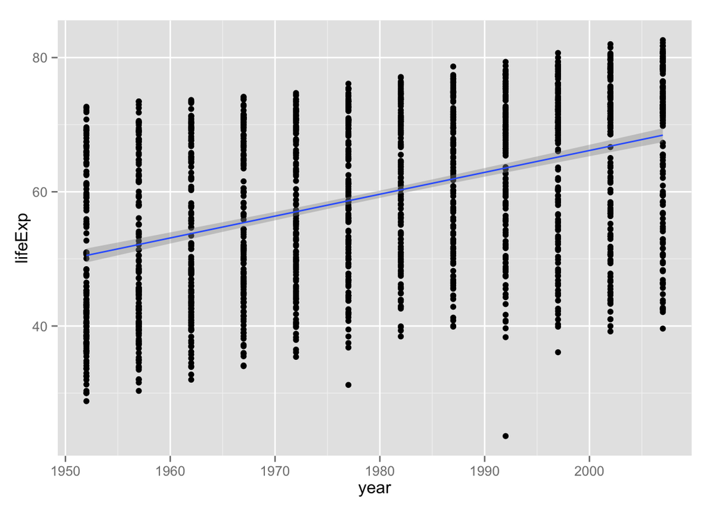

```r
library(ggplot2)

gapminder %>%
  ggplot(aes(x=year,y=lifeExp)) +
    geom_point() +
  geom_smooth(method=lm)
```

**Question 1**: Is there a general trend (e.g., increasing or decreasing) for life expectancy across time? Is this trend linear? (answering this qualitatively from the plot, you will do a statistical analysis of this question shortly)

A slightly different way of making the same plot is looking at the distribution of life expectancy across countries as it changes over time:

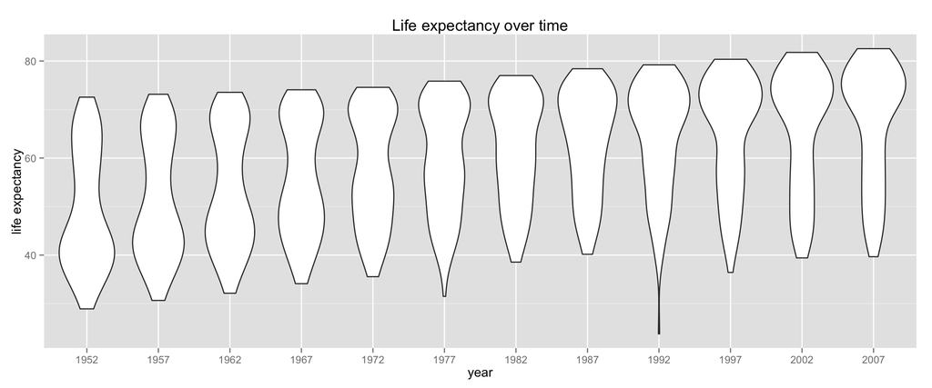

```r
library(dplyr)
library(ggplot2)

gapminder %>%
  ggplot(aes(x=factor(year), y=lifeExp)) +
    geom_violin() +
    labs(title="Life expectancy over time",
         x = "year",
         y = "life expectancy")
```

This type of plot is called a *violin plot*, and it displays the distribution of the variable in the y-axis for each value of the variable in the x-axis.

**Question 2**: How would you describe the distribution of life expectancy across countries for individual years? Is it skewed, or not? Unimodal or not? Symmetric around it’s center?

Based on this plot, consider the following questions.

**Question 3**: Suppose I fit a linear regression model of life expectancy vs. year (treating it as a continuous variable), and test for an association between year and life expectancy, will you reject the null hypothesis of no association?

**Question 4**: What would a violin plot of residuals from the linear model in Question 3 vs. year look like?

**Question 5**: According to the assumptions of the linear regression model, what **should** that violin plot look like?

**Exercise 2**: Fit a linear regression model using the `lm` function for life expectancy vs. year (as a continuous variable). Use the `summary` function to look at the resulting model.

```r
fit <- lm(lifeExp~year, data=gapminder)
summary(fit)
```

```
##
## Call:
## lm(formula = lifeExp ~ year, data = gapminder)
##
## Residuals:
##     Min      1Q  Median      3Q     Max
## -39.949  -9.651   1.697  10.335  22.158
##
## Coefficients:
##               Estimate Std. Error t value Pr(>|t|)
## (Intercept) -585.65219   32.31396  -18.12   <2e-16 ***
## year           0.32590    0.01632   19.96   <2e-16 ***
## ---
## Signif. codes:  0 '***' 0.001 '**' 0.01 '*' 0.05 '.' 0.1 ' ' 1
##
## Residual standard error: 11.63 on 1702 degrees of freedom
## Multiple R-squared:  0.1898, Adjusted R-squared:  0.1893
## F-statistic: 398.6 on 1 and 1702 DF,  p-value: < 2.2e-16
```

**Question 6**: On average, by how much does life expectancy increase every year around the world?

**Question 7**: Do you reject the null hypothesis of no association between year and life expectancy? Why?

**Exercise 3**: Make a violin plot of residuals vs. year for the linear model from Exercise 2.

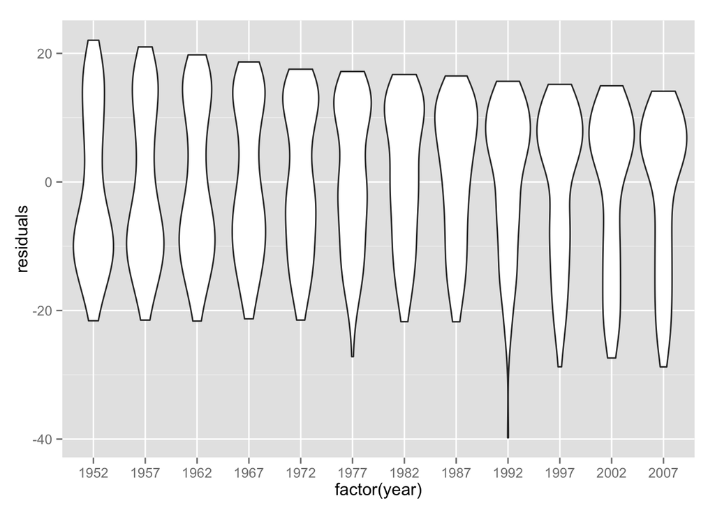

```r
gapminder %>%
  mutate(residuals=residuals(fit)) %>%
  ggplot(aes(x=factor(year), y=residuals)) +
  geom_violin()
```

**Question 8**: Does it match your expectations (Question 4)?